# Coursera Machine Learning Final Project

The Dataset: The data comes from accelerometers on the belt, forearm, arm, and dumbbell of 6 participants. They were asked to perform barbell lifts correctly and incorrectly in 5 different ways. The goal of this project is to predict the manner in which they did the exercise. This is the “classe” variable in the training set.

# Load the library

```r
library(caret)
```

Read the dataset in R

```r
trainUrl <- "http://d396qusza40orc.cloudfront.net/predmachlearn/pml-training.csv"
testUrl <- "http://d396qusza40orc.cloudfront.net/predmachlearn/pml-testing.csv"
training <- read.csv(url(trainUrl))
testing <- read.csv(url(testUrl))
dim(training)
```

```
## [1] 19622   160
```

The training dataset consists of 19622 rows and 160 columns . So there are 160 columns all together. Our dependent variable is “classe”. Let’s see how many of them are A, how many B and C,D or E from the data in training

```r
table(training$classe)
```

```
##
##    A    B    C    D    E
## 5580 3797 3422 3216 3607
```

Data Cleaning: Missing Data: Let’s take a look at what columns have missing values:

```r
summary(training)
```

```
##        X            user_name    raw_timestamp_part_1 raw_timestamp_part_2
##  Min.   :    1   adelmo  :3892   Min.   :1.322e+09    Min.   :   294
##  1st Qu.: 4906   carlitos:3112   1st Qu.:1.323e+09    1st Qu.:252912
##  Median : 9812   charles :3536   Median :1.323e+09    Median :496380
##  Mean   : 9812   eurico  :3070   Mean   :1.323e+09    Mean   :500656
##  3rd Qu.:14717   jeremy  :3402   3rd Qu.:1.323e+09    3rd Qu.:751891
##  Max.   :19622   pedro   :2610   Max.   :1.323e+09    Max.   :998801
##
##           cvtd_timestamp  new_window    num_window      roll_belt
##  28/11/2011 14:14: 1498   no :19216   Min.   :  1.0   Min.   :-28.90
##  05/12/2011 11:24: 1497   yes:  406   1st Qu.:222.0   1st Qu.:  1.10
##  30/11/2011 17:11: 1440               Median :424.0   Median :113.00
##  05/12/2011 11:25: 1425               Mean   :430.6   Mean   : 64.41
##  02/12/2011 14:57: 1380               3rd Qu.:644.0   3rd Qu.:123.00
##  02/12/2011 13:34: 1375               Max.   :864.0   Max.   :162.00
##  (Other)         :11007
##    pitch_belt          yaw_belt       total_accel_belt kurtosis_roll_belt
##  Min.   :-55.8000   Min.   :-180.00   Min.   : 0.00             :19216
##  1st Qu.:  1.7600   1st Qu.: -88.30   1st Qu.: 3.00    #DIV/0!  :   10
##  Median :  5.2800   Median : -13.00   Median :17.00    -1.908453:    2
##  Mean   :  0.3053   Mean   : -11.21   Mean   :11.31    -0.016850:    1
##  3rd Qu.: 14.9000   3rd Qu.:  12.90   3rd Qu.:18.00    -0.021024:    1
##  Max.   : 60.3000   Max.   : 179.00   Max.   :29.00    -0.025513:    1
##                                                        (Other)  :  391
##  kurtosis_picth_belt kurtosis_yaw_belt skewness_roll_belt
##           :19216            :19216              :19216
##  #DIV/0!  :   32     #DIV/0!:  406     #DIV/0!  :    9
##  47.000000:    4                       0.000000 :    4
##  -0.150950:    3                       0.422463 :    2
##  -0.684748:    3                       -0.003095:    1
##  -1.750749:    3                       -0.010002:    1
##  (Other)  :  361                       (Other)  :  389
##  skewness_roll_belt.1 skewness_yaw_belt max_roll_belt     max_picth_belt
##           :19216             :19216     Min.   :-94.300   Min.   : 3.00
##  #DIV/0!  :   32      #DIV/0!:  406     1st Qu.:-88.000   1st Qu.: 5.00
##  0.000000 :    4                        Median : -5.100   Median :18.00
##  -2.156553:    3                        Mean   : -6.667   Mean   :12.92
##  -3.072669:    3                        3rd Qu.: 18.500   3rd Qu.:19.00
##  -6.324555:    3                        Max.   :180.000   Max.   :30.00
##  (Other)  :  361                        NA's   :19216     NA's   :19216
```

[output cut: 313 more lines]

```
##  Min.   :-446.00   Min.   :-1280.0   Min.   :-896.0   Min.   :-973.0
##  1st Qu.:-182.00   1st Qu.: -616.0   1st Qu.:   2.0   1st Qu.: 191.0
##  Median : -39.00   Median : -378.0   Median : 591.0   Median : 511.0
##  Mean   : -55.29   Mean   : -312.6   Mean   : 380.1   Mean   : 393.6
##  3rd Qu.:  26.00   3rd Qu.:  -73.0   3rd Qu.: 737.0   3rd Qu.: 653.0
##  Max.   : 291.00   Max.   :  672.0   Max.   :1480.0   Max.   :1090.0
##
##  classe
##  A:5580
##  B:3797
##  C:3422
##  D:3216
##  E:3607
##
##
```

```r
nacols=training[colSums(is.na(training))>0]
dim(nacols)
```

```
## [1] 19622    67
```

```r
colSums(is.na(nacols))
```

```
##            max_roll_belt           max_picth_belt            min_roll_belt
##                    19216                    19216                    19216
##           min_pitch_belt      amplitude_roll_belt     amplitude_pitch_belt
##                    19216                    19216                    19216
##     var_total_accel_belt            avg_roll_belt         stddev_roll_belt
##                    19216                    19216                    19216
##            var_roll_belt           avg_pitch_belt        stddev_pitch_belt
##                    19216                    19216                    19216
##           var_pitch_belt             avg_yaw_belt          stddev_yaw_belt
##                    19216                    19216                    19216
##             var_yaw_belt            var_accel_arm             avg_roll_arm
##                    19216                    19216                    19216
##          stddev_roll_arm             var_roll_arm            avg_pitch_arm
##                    19216                    19216                    19216
##         stddev_pitch_arm            var_pitch_arm              avg_yaw_arm
##                    19216                    19216                    19216
##           stddev_yaw_arm              var_yaw_arm             max_roll_arm
##                    19216                    19216                    19216
##            max_picth_arm              max_yaw_arm             min_roll_arm
##                    19216                    19216                    19216
##            min_pitch_arm              min_yaw_arm       amplitude_roll_arm
##                    19216                    19216                    19216
##      amplitude_pitch_arm        amplitude_yaw_arm        max_roll_dumbbell
##                    19216                    19216                    19216
##       max_picth_dumbbell        min_roll_dumbbell       min_pitch_dumbbell
##                    19216                    19216                    19216
##  amplitude_roll_dumbbell amplitude_pitch_dumbbell       var_accel_dumbbell
##                    19216                    19216                    19216
##        avg_roll_dumbbell     stddev_roll_dumbbell        var_roll_dumbbell
##                    19216                    19216                    19216
##       avg_pitch_dumbbell    stddev_pitch_dumbbell       var_pitch_dumbbell
##                    19216                    19216                    19216
##         avg_yaw_dumbbell      stddev_yaw_dumbbell         var_yaw_dumbbell
##                    19216                    19216                    19216
##         max_roll_forearm        max_picth_forearm         min_roll_forearm
##                    19216                    19216                    19216
##        min_pitch_forearm   amplitude_roll_forearm  amplitude_pitch_forearm
##                    19216                    19216                    19216
##        var_accel_forearm         avg_roll_forearm      stddev_roll_forearm
##                    19216                    19216                    19216
##         var_roll_forearm        avg_pitch_forearm     stddev_pitch_forearm
##                    19216                    19216                    19216
##        var_pitch_forearm          avg_yaw_forearm       stddev_yaw_forearm
##                    19216                    19216                    19216
##          var_yaw_forearm
##                    19216
```

It looks like we have missing values in the several columns (67). All the 67 columns have 19216 missing values out of 19622 records.We will not get any meaningful insight from these columns.So we can safely remove these columns.

In general, if we have more than 60% of NA values in a particular column, We will drop the column Remove the columns which have more than 60% NA values

```r
train<-training[!colSums(is.na(training))>(nrow(training)*.6)]
dim(train)
```

```
## [1] 19622    93
```

Zero Variance: Zero and near-zero variance predictors happen quite often across samples. Zero variance means datasets come with predictors that take a unique value across samples. For many models (excluding tree-based models), this may cause the model to crash or the fit to be unstable. To remove predictors like those nearZeroVar from the caret package is used. It not only removes predictors that have one unique value across samples (zero variance predictors), but also removes predictors that have large ratio of the frequency of the most common value to the frequency of the second most common value (near-zero variance predictors). Remove zero variance or nearly zero variance columns

```r
badCols <- nearZeroVar(train)
train <- train[, -badCols]
dim(train)
```

```
## [1] 19622    59
```

We can see columns x,user_name,raw_timestamp_part_1, raw_timestamp_part_2, cvtd_timestamp of no use. We can ignore these

```r
train<-train[,-c(1,2,3,4,5)]
```

Identify Correlated Predictors: While there are some models that thrive on correlated predictors (such as pls), other models may benefit from reducing the level of correlation between the predictors. Given a correlation matrix, the findCorrelation function uses the following algorithm to flag predictors for removal.

```r
#Check for corelated variables(dont consider Classe variable)
descrCor <- cor(train[,c(1:53)])
# Check for abolutely corelated variables.There are none.
highCorr <- sum(abs(descrCor[upper.tri(descrCor)]) > 0.999)
```

We set cut off is .75. If more than that we will remove those variables

```r
highlyCorDescr <- findCorrelation(descrCor, cutoff = 0.75)
# Remove highly co related variables
train <- train[, -highlyCorDescr]
dim(train)
```

```
## [1] 19622    33
```

Prediction Algorithms:

Create validation dataset using Data Split: We split the dataset into two, 70% of will be used to train the models and 30% that will be held back as a validation dataset. The validation set will be used to get a second and independent idea of how accurate the best model might actually be. It will also give us out of sample error This gives more concrete estimate of the accuracy of the best model on unseen data by evaluating it on actual unseen data.

```r
intrain<-createDataPartition(y=train$classe,p=0.7,list=FALSE)
train_final <- train[intrain,]
test_final <- train[-intrain,]
```

Test Harness: 5-fold cross validation is used to estimate accuracy. This will split our dataset into 5 parts, train on 4 and test on 1 and repeat for all combinations of train-test splits.

```r
#Create the model
control <- trainControl(method="repeatedcv", number=5)
```

The metric “Accuracy” is used to evaluate models. This is a ratio of the number of correctly predicted instances in divided by the total number of instances in the dataset multiplied by 100 to give a percentage (e.g. 95% accurate). The out of sample will be calculated as (1-accuracy) multiplied by 100 to give a percentage. Build Models: Spot check 4 different algorithms to check wich one gives better accuracy on training dataset: 1. Stochastic Gradient Boosting (Generalized Boosted Modeling GBM) 2. K-Nearest Neighbors (KNN). 3. Classification and Regression Trees (CART). 4. Random Forest(RF). The random number seed is set before each run to ensure that the evaluation of each algorithm is performed using exactly the same data splits. It ensures the results are directly comparable.

```r
seed<-123
## Stochastic Gradient Boosting (Generalized Boosted Modeling)
set.seed(seed)
fit.gbm <- train(classe~., data=train_final, method="gbm", preProc=c("center", "scale"),verbose=F,trControl=control)
# K nearesr neighbor algorithm
set.seed(seed)
fit.knn <- train(classe~., data=train_final, method="knn",  trControl=control)
# CART
set.seed(seed)
fit.cart <- train(classe~., data=train_final, method="rpart", trControl=control)
# Random Forest
set.seed(seed)
fit.rf<- train(classe~., data=train_final, method="rf",  trControl=control)
```

Select the best model: We now have 4 models and accuracy estimations for each. We need to compare the models to each other and select the most accurate.

```r
results <- resamples(list(GBM=fit.gbm, KNN=fit.knn, CART=fit.cart, RandomForest=fit.rf))
#summarize the result of the algorithms as a table.
summary(results)
```

```
##
## Call:
## summary.resamples(object = results)
##
## Models: GBM, KNN, CART, RandomForest
## Number of resamples: 5
##
## Accuracy
##                Min. 1st Qu. Median   Mean 3rd Qu.   Max. NA's
## GBM          0.9902  0.9905 0.9909 0.9909  0.9913 0.9916    0
## KNN          0.8492  0.8592 0.8596 0.8600  0.8635 0.8685    0
## CART         0.5488  0.5597 0.5606 0.5631  0.5615 0.5849    0
## RandomForest 0.9967  0.9971 0.9971 0.9975  0.9982 0.9982    0
##
## Kappa
##                Min. 1st Qu. Median   Mean 3rd Qu.   Max. NA's
## GBM          0.9876  0.9880 0.9885 0.9885  0.9890 0.9894    0
## KNN          0.8093  0.8218 0.8224 0.8230  0.8275 0.8339    0
## CART         0.4192  0.4340 0.4438 0.4435  0.4451 0.4757    0
## RandomForest 0.9959  0.9963 0.9963 0.9968  0.9977 0.9977    0
```

Let’s review the results using a few different visualization techniques to get an idea of the mean and spread of accuracies.

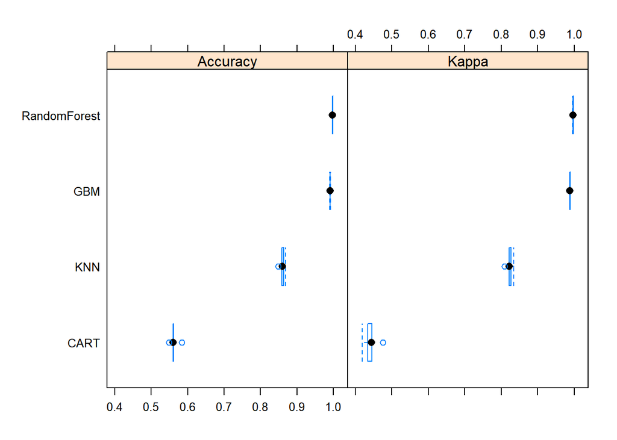

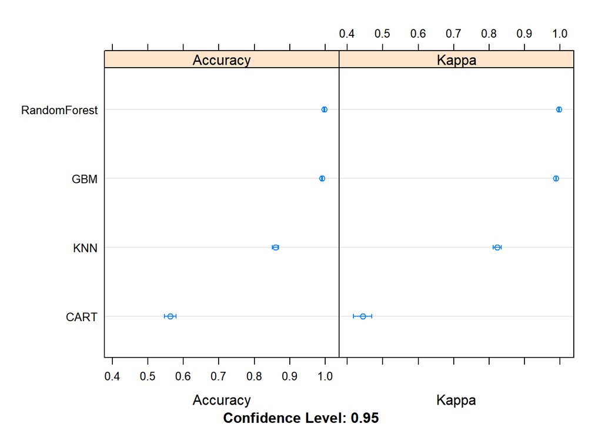

Now we can see Random Forest and GBM algorithm are the most accurate models that we tested. Now we want to get an idea of the accuracy of the model on our validation set. This will give us an independent final check on the accuracy and out of sample error of the best model. It is valuable to keep a validation set just in case you made a slip during training, such as overfitting to the training set or a data leak. Both will result in an overly optimistic result. We can run the Random Forest and GBM model directly on the validation set and summarize the results as a final accuracy score, a confusion matrix and a classification report and out of sample error. Predictions:

```r
# Make prediction in the validation dataset for RF model
predictions <- predict(fit.rf, test_final,type="raw")
table(predictions)
```

```
## predictions
##    A    B    C    D    E
## 1675 1136 1031  960 1083
```

```r
confusionMatrix(predictions, test_final$classe)
```

```
## Confusion Matrix and Statistics
##
##           Reference
## Prediction    A    B    C    D    E
##          A 1674    1    0    0    0
##          B    0 1136    0    0    0
##          C    0    2 1026    3    0
##          D    0    0    0  959    1
##          E    0    0    0    2 1081
##
## Overall Statistics
##
##                Accuracy : 0.9985
##                  95% CI : (0.9971, 0.9993)
##     No Information Rate : 0.2845
##     P-Value [Acc > NIR] : < 2.2e-16
##
##                   Kappa : 0.9981
##  Mcnemar's Test P-Value : NA
##
## Statistics by Class:
##
##                      Class: A Class: B Class: C Class: D Class: E
## Sensitivity            1.0000   0.9974   1.0000   0.9948   0.9991
## Specificity            0.9998   1.0000   0.9990   0.9998   0.9996
## Pos Pred Value         0.9994   1.0000   0.9952   0.9990   0.9982
## Neg Pred Value         1.0000   0.9994   1.0000   0.9990   0.9998
## Prevalence             0.2845   0.1935   0.1743   0.1638   0.1839
## Detection Rate         0.2845   0.1930   0.1743   0.1630   0.1837
## Detection Prevalence   0.2846   0.1930   0.1752   0.1631   0.1840
## Balanced Accuracy      0.9999   0.9987   0.9995   0.9973   0.9993
```

```r
# Make prediction in the validation dataset for GBM model
predictions <- predict(fit.gbm, test_final,type="raw")
table(predictions)
```

```
## predictions
##    A    B    C    D    E
## 1675 1155 1034  951 1070
```

```r
confusionMatrix(predictions, test_final$classe)
```

```
## Confusion Matrix and Statistics
##
##           Reference
## Prediction    A    B    C    D    E
##          A 1672    3    0    0    0
##          B    1 1132   13    6    3
##          C    1    4 1012   15    2
##          D    0    0    1  943    7
##          E    0    0    0    0 1070
##
## Overall Statistics
##
##                Accuracy : 0.9905
##                  95% CI : (0.9877, 0.9928)
##     No Information Rate : 0.2845
##     P-Value [Acc > NIR] : < 2.2e-16
##
##                   Kappa : 0.988
##  Mcnemar's Test P-Value : NA
##
## Statistics by Class:
##
##                      Class: A Class: B Class: C Class: D Class: E
## Sensitivity            0.9988   0.9939   0.9864   0.9782   0.9889
## Specificity            0.9993   0.9952   0.9955   0.9984   1.0000
## Pos Pred Value         0.9982   0.9801   0.9787   0.9916   1.0000
## Neg Pred Value         0.9995   0.9985   0.9971   0.9957   0.9975
## Prevalence             0.2845   0.1935   0.1743   0.1638   0.1839
## Detection Rate         0.2841   0.1924   0.1720   0.1602   0.1818
## Detection Prevalence   0.2846   0.1963   0.1757   0.1616   0.1818
## Balanced Accuracy      0.9990   0.9945   0.9909   0.9883   0.9945
```

We can see that Random forest gives slightly better performance than GBM. The Random Forest algorithm gives an accuracy of 0.9985 or 99.85%. The out of sample error is .0015 or .15%.The confusion matrix provides an indication of the nine errors made. Predictions on testing set: We’re now ready to fit the model to our test data and make our predictions. Prepare the test dataset:

```r
#Remove the classe variable from train_final
train_class<-train_final[,-c(33)]

# Allow only variables in testing that are also in train_final which is used to create the model
colnames<-colnames(train_class)
test_df_final<-testing[colnames]

#Make predictions
predict(fit.rf , test_df_final)
```

```
##  [1] B A B A A E D B A A B C B A E E A B B B
## Levels: A B C D E
```